# TensorFlow 101

Shan-Hung Wu & DataLab

Fall 2019

TensorFlow is a popular end-to-end open source machine learning platform.  
Notice that, in this semester, the version of TensorFlow we are going to use is the newest *2.0*, which is easier to learn and has many amazing features.  
In this lab, we are going to teach you how to setup TensorFlow on your computer and get you familiar with building a typical machine learning pipeline using TensorFlow. Let's get started!

# Environment Setup

## Software requirements

To enable tensorflow-gpu in your environment, following NVIDIA software is required:

- NVIDIA® GPU dirvers - CUDA 10.0 requires 410.x or higher
- CUDA® Toolkit - TensorFlow supports CUDA 10.0 (TensorFlow >= 1.13.0)
- cuDNN SDK (>= 7.4.1)

Please refer to official TensorFlow website([GPU Support](https://www.tensorflow.org/install/gpu)) for more detailed and latest information.

After installing CUDA Toolkit, you should see the version of cuda is 10.0.

```python
!nvcc --version
```

```
nvcc: NVIDIA (R) Cuda compiler driver
Copyright (c) 2005-2018 NVIDIA Corporation
Built on Sat_Aug_25_21:08:01_CDT_2018
Cuda compilation tools, release 10.0, V10.0.130
```

And you can also check GPU utilization after driver installation.

```python
!nvidia-smi
```

```
Mon Oct  7 03:33:07 2019
+-----------------------------------------------------------------------------+
| NVIDIA-SMI 418.43       Driver Version: 418.43       CUDA Version: 10.1     |
|-------------------------------+----------------------+----------------------+
| GPU  Name        Persistence-M| Bus-Id        Disp.A | Volatile Uncorr. ECC |
| Fan  Temp  Perf  Pwr:Usage/Cap|         Memory-Usage | GPU-Util  Compute M. |
|===============================+======================+======================|
|   0  GeForce RTX 208...  Off  | 00000000:02:00.0 Off |                  N/A |
| 27%   25C    P8    19W / 250W |     10MiB / 10989MiB |      0%      Default |
+-------------------------------+----------------------+----------------------+
|   1  GeForce RTX 208...  Off  | 00000000:03:00.0 Off |                  N/A |
| 27%   29C    P8    12W / 250W |   6849MiB / 10989MiB |      0%      Default |
+-------------------------------+----------------------+----------------------+
|   2  GeForce RTX 208...  Off  | 00000000:82:00.0 Off |                  N/A |
| 40%   71C    P2   228W / 250W |  10967MiB / 10989MiB |     58%      Default |
+-------------------------------+----------------------+----------------------+
|   3  GeForce RTX 208...  Off  | 00000000:83:00.0 Off |                  N/A |
| 27%   31C    P8    15W / 250W |     10MiB / 10989MiB |      0%      Default |
+-------------------------------+----------------------+----------------------+

+-----------------------------------------------------------------------------+
| Processes:                                                       GPU Memory |
|  GPU       PID   Type   Process name                             Usage      |
|=============================================================================|
|    1      7260      C   ...conda3/envs/tensorflow_2beta/bin/python  6839MiB |
|    2     15259      C   ...e/test/anaconda3/envs/tf2_rc/bin/python 10925MiB |
+-----------------------------------------------------------------------------+
```

## Installing TensorFlow

You can easily install gpu-version tensorflow via pip.

> pip install tensorflow-gpu

Make sure it is `pip install tensorflow-gpu` not `pip install tensorflow`.

To test whether the tensorflow is installed, you can check it via the following commands.

```python
import tensorflow as tf
print(tf.__version__)
```

```
2.0.0
```

It should show the tensorflow version you installed without any exception.

## CUDA Driver installation Workaround

You can install cudnn via Anaconda.

> conda install cudnn=7.6.0=cuda10.0_0

This command will install corresponding CUDA Toolkit and cuDNN SDK.  
The only driver you have to install manually is the NVIDIA driver.

## Google Colab

Installing all the dependencies of tensorflow is a pain in the ass. Google Colab provides a jupyter notebook environment that requires no setup with free GPU.  
You can easily access Google Colab via your Google account and play around with tensorflow. For example, following colab notebook gives you a beginner guide for tensorflow 2.0: [TensorFlow 2 quickstart for beginners](https://colab.research.google.com/github/tensorflow/docs/blob/master/site/en/tutorials/quickstart/beginner.ipynb). However, there are few contraints when using Google Colab:

- 12 hours time limit
- [limited GPU RAM](https://stackoverflow.com/questions/48750199/google-colaboratory-misleading-information-about-its-gpu-only-5-ram-available)

As a result, we highly recommend you to install tensorflow on your own machine, while colab is still a good place for you to get familiar with tensorflow.

# Getting Started with TensorFlow

Originally developed by Google Brain, TensorFlow is an open source library which provides a variety of functions and classes used to conduct machine learning.

The benefits of using TensorFlow include:

- Python API
- Portability: can be distributed on multiple CPUs or GPUs as well as on mobile devices
- Flexibility: can run on different devices e.g. Raspberry Pi, Android, iOS, Windows, Linux
- Visualization: visualize the training process via TensorBoard
- Checkpoints: manage trained models
- Auto-differentiation
- Large community

Later on, we will try to:

- Load dataset via `tf.keras.datasets`
- Build model via high-level keras api `tf.keras.models.Sequential`
- Build model by subclassing keras model `tf.keras.Model`
- Boost performance by `tf.function`
- Customize gradient flow by `tf.custom_gradient`

Last, we will talk about:

- What is Word2Vec?
- Assignment: Build a Word2Vec model via TensorFlow

## Load Dataset via tf.keras.dataset

Reference:

- TensorFlow API: [tf.keras.datasets](https://www.tensorflow.org/versions/r2.0/api_docs/python/tf/keras/datasets)

Currently, tf.keras.dataset supports 7 datasets. Including:

- `mnist` module: MNIST handwritten digits dataset.
- `cifar10` module: CIFAR10 small images classification dataset.
- `cifar100` module: CIFAR100 small images classification dataset.
- `fashion_mnist` module: Fashion-MNIST dataset.
- `imdb` module: IMDB sentiment classification dataset.
- `boston_housing` module: Boston housing price regression dataset.
- `reuters` module: Reuters topic classification dataset.

In this lab, we will use `mnist` to demo how to build a neural network.

```python
import tensorflow as tf
```

By default, TensorFlow maps nearly all of the GPU memory of all GPUs (subject to [CUDA_VISIBLE_DEVICES](https://docs.nvidia.com/cuda/cuda-c-programming-guide/index.html#env-vars)) visible to the process.  
In some cases it is desirable for the process to only allocate a subset of the available memory, or to only grow the memory usage as is needed by the process. For example, you want to train multiple small models with one GPU at the same time.  
By calling [tf.config.experimental.set_memory_growth](https://www.tensorflow.org/api_docs/python/tf/config/experimental/set_memory_growth), which attempts to allocate only as much GPU memory in needed for the runtime allocations: it starts out allocating very little memory, and as the program gets run and more GPU memory is needed, we extend the GPU memory region allocated to the TensorFlow process.

```python
gpus = tf.config.experimental.list_physical_devices('GPU')
if gpus:
    try:
        # Restrict TensorFlow to only use the fourth GPU
        tf.config.experimental.set_visible_devices(gpus[2], 'GPU')

        # Currently, memory growth needs to be the same across GPUs
        for gpu in gpus:
            tf.config.experimental.set_memory_growth(gpu, True)
        logical_gpus = tf.config.experimental.list_logical_devices('GPU')
        print(len(gpus), "Physical GPUs,", len(logical_gpus), "Logical GPUs")
    except RuntimeError as e:
        # Memory growth must be set before GPUs have been initialized
        print(e)
```

```
4 Physical GPUs, 1 Logical GPUs
```

Load MNIST and normalize the pixel values from [0., 255.] to [0., 1.].

```python
mnist = tf.keras.datasets.mnist

(x_train, y_train), (x_test, y_test) = mnist.load_data()
x_train, x_test = x_train / 255.0, x_test / 255.0
```

```
Training dataset: (60000, 28, 28)
Testing dataset: (10000, 28, 28)
label: 5
```

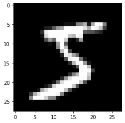

```python
%matplotlib inline
import matplotlib.pyplot as plt

print("Training dataset: {}".format(x_train.shape))
print("Testing dataset: {}".format(x_test.shape))
print("label: {}".format(y_train[0]))
plt.imshow(x_train[0], cmap='gray')
plt.show()
```

Import layers from keras API

```python
from tensorflow.keras.layers import Flatten, Dense, Dropout
```

## Build model via tf.keras.Sequential

Reference:

- TensorFlow guide: [TensorFlow 2 quickstart for beginners](https://www.tensorflow.org/beta/tutorials/quickstart/beginner)
- TensorFlow API: [tf.keras.Sequential](https://www.tensorflow.org/versions/r2.0/api_docs/python/tf/keras/Sequential)

Stack layers by `tf.keras.Sequential`, and choose an optimizer and loss function for training.

```python
model = tf.keras.Sequential([
    tf.keras.layers.Flatten(input_shape=(28, 28)),
    tf.keras.layers.Dense(128, activation='relu'),
    tf.keras.layers.Dropout(0.2),
    tf.keras.layers.Dense(10, activation='softmax')
])

model.compile(optimizer='adam',
              loss='sparse_categorical_crossentropy',
              metrics=['accuracy'])
```

```python
model.summary()
```

```
Model: "sequential"
_________________________________________________________________
Layer (type)                 Output Shape              Param #
=================================================================
flatten (Flatten)            (None, 784)               0
_________________________________________________________________
dense (Dense)                (None, 128)               100480
_________________________________________________________________
dropout (Dropout)            (None, 128)               0
_________________________________________________________________
dense_1 (Dense)              (None, 10)                1290
=================================================================
Total params: 101,770
Trainable params: 101,770
Non-trainable params: 0
_________________________________________________________________
```

```python
model.fit(x_train, y_train, batch_size=32, epochs=5)

model.evaluate(x_test, y_test, verbose=2)
```

```
Train on 60000 samples
10000/1 - 1s - loss: 0.0395 - accuracy: 0.9767
```

```
[0.07543366481391713, 0.9767]
```

## Build model by subclassing keras model tf.keras.Model

Reference:

- TensorFlow guide: [TensorFlow 2 quickstart for experts](https://www.tensorflow.org/beta/tutorials/quickstart/advanced)
- TensorFlow API: [tf.keras.Model](https://www.tensorflow.org/versions/r2.0/api_docs/python/tf/keras/Model)

```python
# Destroys the current TF graph and creates a new one.
tf.keras.backend.clear_session()
```

Use `tf.data` to batch and shuffle the dataset:

```python
train_ds = tf.data.Dataset.from_tensor_slices((x_train, y_train)).shuffle(10000).batch(32)
test_ds = tf.data.Dataset.from_tensor_slices((x_test, y_test)).batch(32)
```

Build the `tf.keras` model by subclassing `tf.keras.Model`:

```python
from tensorflow.keras import Model

class MyModel(Model):
    def __init__(self):
        super(MyModel, self).__init__()
        self.flatten = Flatten()
        self.dropout = Dropout(0.2)
        self.d1 = Dense(128, activation='relu')
        self.d2 = Dense(10, activation='softmax')

    def call(self, x):
        x = self.flatten(x)
        x = self.d1(x)
        x = self.dropout(x)
        return self.d2(x)

model = MyModel()
```

The layers that model consists of are as same as the sequential model above.

```python
model.build(input_shape=(None, 28, 28))
model.summary()
```

```
Model: "my_model"
_________________________________________________________________
Layer (type)                 Output Shape              Param #
=================================================================
flatten (Flatten)            multiple                  0
_________________________________________________________________
dropout (Dropout)            multiple                  0
_________________________________________________________________
dense (Dense)                multiple                  100480
_________________________________________________________________
dense_1 (Dense)              multiple                  1290
=================================================================
Total params: 101,770
Trainable params: 101,770
Non-trainable params: 0
_________________________________________________________________
```

Choose an optimizer and loss function for training:

```python
loss_object = tf.keras.losses.SparseCategoricalCrossentropy()

optimizer = tf.keras.optimizers.Adam()
```

Select metrics to measure the loss and the accuracy of the model. These metrics can help us to accumulate the values over epochs and then print the overall result.

```python
train_loss = tf.keras.metrics.Mean(name='train_loss')
train_accuracy = tf.keras.metrics.SparseCategoricalAccuracy(name='train_accuracy')

test_loss = tf.keras.metrics.Mean(name='test_loss')
test_accuracy = tf.keras.metrics.SparseCategoricalAccuracy(name='test_accuracy')
```

Use `tf.GradientTape` to collect gradient and train the model.

```python
@tf.function
def train_step(images, labels):
    with tf.GradientTape() as tape:
        predictions = model(images)
        loss = loss_object(labels, predictions)
    gradients = tape.gradient(loss, model.trainable_variables)
    optimizer.apply_gradients(zip(gradients, model.trainable_variables))

    train_loss(loss)
    train_accuracy(labels, predictions)
```

```python
@tf.function
def test_step(images, labels):
    predictions = model(images)
    t_loss = loss_object(labels, predictions)

    test_loss(t_loss)
    test_accuracy(labels, predictions)
```

Notice that the function decorated by `tf.function` will be converted to graph automatically. This allows the TensorFlow runtime to apply optimizations and exploit parallelism to boost computation performance. We will talk more about `tf.function` in the later section.

Train and evaluate the model:

```python
EPOCHS = 5

for epoch in range(EPOCHS):
    for images, labels in train_ds:
        train_step(images, labels)

    for test_images, test_labels in test_ds:
        test_step(test_images, test_labels)

    template = 'Epoch {:0}, Loss: {:.2f}, Accuracy: {:.2f}, Test Loss: {:.2f}, Test Accuracy: {:.2f}'
    print (template.format(epoch+1,
                           train_loss.result(),
                           train_accuracy.result()*100,
                           test_loss.result(),
                           test_accuracy.result()*100))

    # Reset the metrics for the next epoch
    train_loss.reset_states()
    train_accuracy.reset_states()
    test_loss.reset_states()
    test_accuracy.reset_states()
```

[output not shown]

## Boost performance by tf.function

Reference:

- TensorFlow Guide: [Better performance with tf.function and AutoGraph](https://www.tensorflow.org/guide/function)
- TensorFlow API: [tf.function](https://www.tensorflow.org/versions/r2.0/api_docs/python/tf/function)
- video: [tf.function and Autograph](https://www.youtube.com/watch?v=Up9CvRLIIIw)

TensorFlow 1.X requires users to manually stitch together an [abstract syntax tree](https://en.wikipedia.org/wiki/Abstract_syntax_tree) (the graph) by making `tf.*` API calls. It then requires users to manually compile the abstract syntax tree by passing a set of output tensors and input tensors to a `session.run()` call. TensorFlow 2.0 executes eagerly (like Python normally does) and in 2.0, graphs and sessions should feel like implementation details.  
TF 2.0 brings together the ease of eager execution and the power of TF 1.0. At the center of this merger is `tf.function`, which allows you to transform a subset of Python syntax into portable, high-performance TensorFlow graphs.

tl;dr

- ignore graph and session, which is replaced by `eager execution` and `tf.function` in TensorFlow 2.x

```python
# TensorFlow 1.x style
# Graph and Session
with tf.Graph().as_default():
    a = tf.constant(20.0)
    print(a)
    with tf.compat.v1.Session() as sess:
        print(sess.run(a))
```

```
Tensor("Const:0", shape=(), dtype=float32)
20.0
```

```python
# TensorFlow 2 with Eager Execution by default
# no need to set up Graph and Session
a = tf.constant(20.0)
print(a)
print(a.numpy())
```

```
tf.Tensor(20.0, shape=(), dtype=float32)
20.0
```

Create two function with same operation. Except funciton `g` is decorated with `tf.function` to compute in graph mode.

```python
def f(x, y):
    return tf.reduce_mean(tf.multiply(x ** 2, 3) + y)

@tf.function
def g(x, y):
    return tf.reduce_mean(tf.multiply(x ** 2, 3) + y)
```

```python
x = tf.constant([[2.0, 3.0]])
y = tf.constant([[3.0, -2.0]])
```

```python
# `f` and `g` will return the same value, but `g` will be executed as a
# TensorFlow graph.
assert f(x, y).numpy() == g(x, y).numpy()
```

```python
%time for i in range(10000): f(x, y)
```

```
CPU times: user 5.6 s, sys: 418 ms, total: 6.02 s
Wall time: 3.64 s
```

```python
%time for i in range(10000): g(x, y)
```

```
CPU times: user 4.82 s, sys: 550 ms, total: 5.37 s
Wall time: 2.62 s
```

### Notes:

If your code uses multiple functions, you don't need to annotate them all - any functions called from an annotated function will also run in graph mode. Decorate the outermost function only. `tf.fucntion` will trace all the functions called inside and convert all of them into graph.  
For more limitations of autograph, please refer to [AutoGraph Capabilities and Limitations](https://github.com/tensorflow/tensorflow/blob/master/tensorflow/python/autograph/g3doc/reference/limitations.md).

## Customize gradient flow by tf.custom_gradient

Reference:

- TensorFlow API: [tf.custom_gradient](https://www.tensorflow.org/versions/r2.0/api_docs/python/tf/custom_gradient)

Consider the following function that commonly occurs in the computation of cross entropy and log likelihoods:

$$y=\log_e(1+e^x)$$

```python
def log1pexp(x):
    return tf.math.log(1 + tf.exp(x))
```

The derivative of y is:

$$\frac{dy}{dx}=\frac{e^x}{1+e^x}=1-\frac{1}{1+e^x}$$

As a result, if x = 100, `dy/dx` should be 1.  
However, due to numerical instability, the gradient evaluated at x=100 is NaN

```python
x = tf.constant(100.)
with tf.GradientTape() as g:
    g.watch(x)
    y = log1pexp(x)
dy_dx = g.gradient(y, x) # Will be evaluated as NaN.
dy_dx.numpy()
```

```
nan
```

The gradient expression can be analytically simplified to provide numerical stability:

```python
@tf.custom_gradient
def log1pexp(x):
    e = tf.exp(x)
    def grad(dy):
        return dy * (1 - 1 / (1 + e))
    return tf.math.log(1 + e), grad
```

```python
x = tf.constant(100.)
with tf.GradientTape() as g:
    g.watch(x)
    y = log1pexp(x)
dy_dx = g.gradient(y, x) # Will be 1.0 when evaluated.
dy_dx.numpy()
```

```
1.0
```

# Word2Vec

Reference:

- [Vector Representations of Words](https://www.tensorflow.org/tutorials/representation/word2vec)

Word2Vec is a computationally-efficient model that learns to embed words into vectors. The goal is to map words that have similar meanings close to each other.

## Why represent words as vectors?

When dealing with words, a straightforward way would be treating each word as discrete symbols. For instance, `cat` as `2` and `dog` as `1`. However, these symbols carry no information about the original word, making it impossible for us to infer the relationship between cats and dogs (both are four-legged animals and both are pets) based on the symbols alone. Hence, to successfully learn the relationship between them, we might need a large amount of training data.  
On the other hand, **Vector space models (VSMs)** which represent words as vectors can help overcome these obstacles. This is based on a key observation that **semantically similar words are often used interchangeably in different contexts**. For example, the words `cat` and `dog` may both appear in a context "___ is my favorite pet." When feeding `cat` and `dog` into the NN to predict their nearby words, these two words will be likely to share the same/similar hidden representation in order to predict the same/similar nearby words.

## Skip-Gram and CBOW

Word2Vec comes in two variants **Skip-Gram** and **CBOW (Continuous Bag-Of-Words)**. Algorithmically, these models are similar. CBOW predicts the target words using its neighborhood(context) whereas Skip-Gram does the inverse, which is to predict context words from the target words. For example, given the sentence `the quick brown fox jumped over the lazy dog`. Defining the context words as the word to the left and right of the target word, CBOW will be trained on the dataset:

`([the, brown], quick), ([quick, fox], brown), ([brown, jumped], fox)...`

where CBOW tries to predict the target word `quick` from the context words in brackets `[the, brown]`, and predict `brown` from `[quick, fox]` and so on. However, with Skip-Gram, the dataset becomes

`(quick, the), (quick, brown), (brown, quick), (brown, fox), ...`

where Skip-Gram predicts the context word `the`, `brown` with the target word `quick`. Statistically, CBOW smoothes over a lot of the distributional information (by treating an entire context as one example). For the most part, this turns out to be a useful thing for smaller datasets. On the other hand, Skip-Gram treats each context-target pair as a new observation and is shown to be able to capture the semantics better when we have a large dataset.

[output not shown]

Note that the tasks described above are only used to train the neural network, we don’t use the neural network for the task we trained it on. What we want is the weights of the hidden layer, the "embedding matrix".

For the rest of the tutorial, we will focus on the **Skip-Gram** model.

## Scaling up with noise-contrastive training

Neural probabilistic language models are traditionally trained using the [maximum likelihood](https://en.wikipedia.org/wiki/Maximum_likelihood_estimation) (ML) principle to maximize the probability of the next word $w_t$ (for "target") given the previous words $h$ (for "history") in terms of a [softmax function](https://en.wikipedia.org/wiki/Softmax_function), $$ P(w_t|h)=\textrm{softmax}(\textrm{score}(w_t,h))=\frac{\textrm{exp}\{\textrm{score}(w_t,h)\}}{\sum_{\textrm{Word w in Vocab}}\textrm{exp}\{\textrm{score}(w,h)\}} $$

where $\textrm{score}(w_t,h)$ computes the compatibility of word $w_t$ with the context $h$ (a dot product is commonly used). We train this model by maximizing its [log-likelihood](https://en.wikipedia.org/wiki/Likelihood_function) on the training set, i.e. by maximizing $$ J_\textrm{ML}=\log(P(w_t|h))=\textrm{score}(w_t,h)-\log\Bigg(\sum_{\textrm{Word w in Vocab}}\textrm{exp}\{\textrm{score}(w,h)\}\Bigg) $$

This yields a properly normalized probabilistic model for language modeling. However this is very expensive, because we need to compute and normalize each probability using the score for all other $V$ words $w$ in the current context $h$, *at every training step*.

[figure not shown]

On the other hand, for feature learning in word2vec we do not need a full probabilistic model. The **CBOW** and **skip-gram** models are instead trained using a binary classification objective ([logistic regression](https://en.wikipedia.org/wiki/Logistic_regression)) to discriminate the real target words $w_t$ from $k$ imaginary (noise) words $\tilde{w}$, in the same context. We illustrate this below for a CBOW model. For skip-gram the direction is simply inverted.

[figure not shown]

Mathematically, the objective (for each example) is to maximize $$ J_\textrm{NEG}=\log Q_\theta(D=1|w_t,h)+k\mathop{\mathbb{E}}_{\tilde{w} \sim P_{noise}}[\log Q_\theta(D=0|\tilde{w},h)] $$ where $\log Q_\theta(D=1|w_t,h)$ is the binary logistic regression probability under the model of seeing the word $w_t$ in the context $h$ in the dataset $D$, calculated in terms of the learned embedding vectors $\theta$. In practice we approximate the expectation by drawing $k$ contrastive words from the noise distribution.

## Application: Skip gram model with NCE loss

### The Dataset

The dataset we use is **text8**, which is the first 100 MB of cleaned text of the English Wikipedia dump on Mar. 3, 2006. While 100MB is not enough to train really good embeddings, we can still see some interesting relations. Splitting the text by blank space, we can find that there are 17,005,207 tokens in total.

#### Preparing training data

To generate batches for training, several functions defined below are used. First, we read the data into the memory and build the vocabulary using a number of most commonly seen words. Meanwhile, we build two dictionaries, a dictionary that translates words to indices and another which does the reverse. Then, for every word in the text selected as the center word, pair them with one of the context words. Finally, a python generator which generates a batch of pairs of center-target pairs.

```python
import tensorflow as tf
import numpy as np
import random
```

```python
gpus = tf.config.experimental.list_physical_devices('GPU')
if gpus:
    try:
        # Restrict TensorFlow to only use the fourth GPU
        tf.config.experimental.set_visible_devices(gpus[2], 'GPU')

        # Currently, memory growth needs to be the same across GPUs
        for gpu in gpus:
            tf.config.experimental.set_memory_growth(gpu, True)
        logical_gpus = tf.config.experimental.list_logical_devices('GPU')
        print(len(gpus), "Physical GPUs,", len(logical_gpus), "Logical GPUs")
    except RuntimeError as e:
        # Memory growth must be set before GPUs have been initialized
        print(e)
```

```
4 Physical GPUs, 1 Logical GPUs
```

```python
import os
import urllib

# Download the data.
DOWNLOAD_URL = 'http://mattmahoney.net/dc/'
DATA_FOLDER = "data"
FILE_NAME = "text8.zip"
EXPECTED_BYTES = 31344016

def make_dir(path):
    """ Create a directory if there isn't one already. """
    try:
        os.mkdir(path)
    except OSError:
        pass

def download(file_name, expected_bytes):
    """ Download the dataset text8 if it's not already downloaded """
    local_file_path = os.path.join(DATA_FOLDER, file_name)
    if os.path.exists(local_file_path):
        print("Dataset ready")
        return local_file_path
    file_name, _ = urllib.request.urlretrieve(os.path.join(DOWNLOAD_URL, file_name), local_file_path)
    file_stat = os.stat(local_file_path)
    if file_stat.st_size == expected_bytes:
        print('Successfully downloaded the file', file_name)
    else:
        raise Exception(
              'File ' + file_name +
              ' might be corrupted. You should try downloading it with a browser.')
    return local_file_path

make_dir(DATA_FOLDER)
file_path = download(FILE_NAME, EXPECTED_BYTES)
```

```
Dataset ready
```

```python
import zipfile

# Read the data into a list of strings.
def read_data(file_path):
    """ Read data into a list of tokens """
    with zipfile.ZipFile(file_path) as f:
        # tf.compat.as_str() converts the input into the string
        data = tf.compat.as_str(f.read(f.namelist()[0])).split()
    return data

vocabulary = read_data(file_path)
print('Data size', len(vocabulary))
```

```
Data size 17005207
```

#### Build the dictionary

```python
import collections
# Build the dictionary and replace rare words with UNK token.
def build_dataset(words, n_words):
    """ Create two dictionaries and count of occuring words
        - word_to_id: map of words to their codes
        - id_to_word: maps codes to words (inverse word_to_id)
        - count: map of words to count of occurrences
    """
    count = [['UNK', -1]]
    count.extend(collections.Counter(words).most_common(n_words - 1))
    word_to_id = dict() # (word, id)
    # record word id
    for word, _ in count:
        word_to_id[word] = len(word_to_id)
    id_to_word = dict(zip(word_to_id.values(), word_to_id.keys())) # (id, word)
    return word_to_id, id_to_word, count

def convert_words_to_id(words, dictionary, count):
    """ Replace each word in the dataset with its index in the dictionary """
    data_w2id = []
    unk_count = 0
    for word in words:
        # return 0 if word is not in dictionary
        index = dictionary.get(word, 0)
        if index == 0:
            unk_count += 1
        data_w2id.append(index)
    count[0][1] = unk_count
    return data_w2id, count
```

```python
"""Filling 4 global variables:
# data_w2id - list of codes (integers from 0 to vocabulary_size-1).
              This is the original text but words are replaced by their codes
# count - map of words(strings) to count of occurrences
# word_to_id - map of words(strings) to their codes(integers)
# id_to_word - maps codes(integers) to words(strings)
"""

vocabulary_size = 50000
word_to_id, id_to_word, count = build_dataset(vocabulary, vocabulary_size)
data_w2id, count = convert_words_to_id(vocabulary, word_to_id, count)
del vocabulary  # reduce memory.
```

```python
print('Most common words (+UNK)', count[:5])
print('Sample data: {}'.format(data_w2id[:10]))
print([id_to_word[i] for i in data_w2id[:10]])
```

```
Most common words (+UNK) [['UNK', 418391], ('the', 1061396), ('of', 593677), ('and', 416629), ('one', 411764)]
Sample data: [5234, 3081, 12, 6, 195, 2, 3134, 46, 59, 156]
['anarchism', 'originated', 'as', 'a', 'term', 'of', 'abuse', 'first', 'used', 'against']
```

```python
# utility function
def generate_sample(center_words, context_window_size):
    """ Form training pairs according to the skip-gram model. """
    for idx, center in enumerate(center_words):
        context = random.randint(1, context_window_size)
        # get a random target before the center word
        for target in center_words[max(0, idx - context) : idx]:
            yield center, target
        # get a random target after the center word
        for target in center_words[idx + 1 : idx + context + 1]:
            yield center, target

def batch_generator(data, skip_window, batch_size):
    """ Group a numeric stream into batches and yield them as Numpy arrays. """
    single_gen = generate_sample(data, skip_window)
    while True:
        center_batch = np.zeros(batch_size, dtype=np.int32)
        target_batch = np.zeros([batch_size, 1], dtype=np.int32)
        for idx in range(batch_size):
            center_batch[idx], target_batch[idx] = next(single_gen)
        yield center_batch, target_batch
```

### Skip-gram word2vec model

Reference:

- [Writing custom layers and models with Keras](https://www.tensorflow.org/guide/keras/custom_layers_and_models)

```python
## some training settings
training_steps = 100000
skip_step = 2000
ckpt_dir = "checkpoints/word2vec_simple"

## some hyperparameters
batch_size = 128
embed_size = 128
num_sampled = 64
learning_rate = 1.0
```

- Functional API

```python
from tensorflow.keras.layers import Layer

class embedding_lookup(Layer):
    def __init__(self):
        super(embedding_lookup, self).__init__()
        embedding_init = tf.keras.initializers.GlorotUniform()
        self.embedding_matrix = self.add_weight(name="embedding_matrix",
                                                trainable=True,
                                                shape=[vocabulary_size, embed_size],
                                                initializer=embedding_init)

    def call(self, inputs):
        center_words = inputs
        embedding = tf.nn.embedding_lookup(self.embedding_matrix,
                                           center_words,
                                           name='embedding')
        return embedding

class nce_loss(Layer):
    def __init__(self):
        super(nce_loss, self).__init__()
        nce_w_init = tf.keras.initializers.TruncatedNormal(stddev=1.0/(embed_size ** 0.5))
        self.nce_weight = self.add_weight(name='nce_weight',
                                          trainable=True,
                                          shape=[vocabulary_size, embed_size],
                                          initializer=nce_w_init)
        self.nce_bias = self.add_weight(name='nce_bias',
                                        trainable=True,
                                        shape=[vocabulary_size],
                                        initializer=tf.keras.initializers.Zeros)

    def call(self, inputs):
        embedding, target_words = inputs[0], inputs[1]
        loss = tf.reduce_mean(tf.nn.nce_loss(weights=self.nce_weight,
                                             biases=self.nce_bias,
                                             labels=target_words,
                                             inputs=embedding,
                                             num_sampled=num_sampled,
                                             num_classes=vocabulary_size),
                                             name='loss')
        return loss
```

```python
from tensorflow.keras import Model, Input

center_words = Input(shape=(), name='center_words', dtype='int32')
target_words = Input(shape=(1), name='target_words', dtype='int32')

embedding = embedding_lookup()(center_words)
loss = nce_loss()((embedding, target_words))

word2vec = Model(name='word2vec',
                 inputs=[center_words, target_words],
                 outputs=[loss])
```

```python
## geneartor for `tf.data.Dataset`
def gen():
    """ Return a python generator that generates batches. """
    yield from batch_generator(data_w2id, 2, batch_size)

dataset = tf.data.Dataset.from_generator(gen,
                                         (tf.int32, tf.int32),
                                         (tf.TensorShape([batch_size]), tf.TensorShape([batch_size, 1])))\
                         .repeat()
```

```python
train_loss = tf.keras.metrics.Mean(name='train_loss')
optimizer = tf.keras.optimizers.SGD(learning_rate=learning_rate)
```

```python
@tf.function
def train_step(center_words, target_words):
    with tf.GradientTape() as tape:
        loss = word2vec([center_words, target_words])
    gradients = tape.gradient(loss, word2vec.trainable_variables)
    optimizer.apply_gradients(zip(gradients, word2vec.trainable_variables))

    train_loss(loss)
```

```python
x = []
y = []
for step, (center_words, target_words) in enumerate(dataset):
    if step == training_steps:
        break
    train_step(center_words, target_words)

    if ((step+1) % skip_step) == 0:
        template = 'Step {:0}, Loss: {:.2f}'
        x.append(step+1)
        y.append(train_loss.result())
        print (template.format(step+1, train_loss.result()))
        train_loss.reset_states()
```

```
Step 2000, Loss: 113.87
Step 4000, Loss: 53.18
Step 6000, Loss: 34.23
Step 8000, Loss: 23.33
Step 10000, Loss: 18.39
Step 12000, Loss: 14.57
Step 14000, Loss: 12.05
Step 16000, Loss: 10.31
Step 18000, Loss: 9.13
Step 20000, Loss: 8.43
Step 22000, Loss: 7.84
Step 24000, Loss: 7.29
Step 26000, Loss: 6.66
Step 28000, Loss: 6.57
Step 30000, Loss: 6.49
Step 32000, Loss: 5.90
Step 34000, Loss: 5.91
Step 36000, Loss: 5.93
Step 38000, Loss: 5.97
Step 40000, Loss: 5.78
Step 42000, Loss: 5.79
Step 44000, Loss: 5.41
Step 46000, Loss: 5.59
Step 48000, Loss: 5.51
Step 50000, Loss: 5.38
Step 52000, Loss: 5.37
Step 54000, Loss: 5.39
Step 56000, Loss: 5.36
Step 58000, Loss: 4.90
Step 60000, Loss: 5.26
Step 62000, Loss: 5.16
Step 64000, Loss: 5.14
Step 66000, Loss: 5.02
Step 68000, Loss: 5.14
Step 70000, Loss: 5.00
Step 72000, Loss: 5.10
Step 74000, Loss: 4.86
Step 76000, Loss: 4.90
Step 78000, Loss: 4.95
Step 80000, Loss: 5.12
Step 82000, Loss: 4.98
Step 84000, Loss: 4.94
Step 86000, Loss: 4.94
Step 88000, Loss: 4.95
Step 90000, Loss: 4.88
Step 92000, Loss: 4.96
Step 94000, Loss: 4.86
Step 96000, Loss: 4.81
Step 98000, Loss: 4.65
Step 100000, Loss: 4.71
```

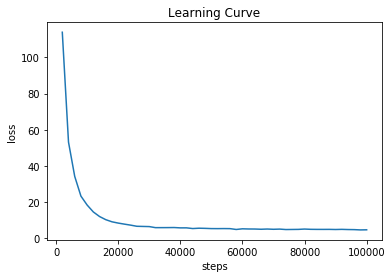

```python
%matplotlib inline
import matplotlib.pyplot as plt

plt.xlabel("steps")
plt.ylabel("loss")
plt.title("Learning Curve")
plt.plot(x, y)
plt.show()
```

### Visualizing the learned embeddings

After training we can visualize the learned embeddings using [t-SNE](https://en.wikipedia.org/wiki/T-distributed_stochastic_neighbor_embedding).  
We can see that similar words are near to each other.

```python
# get embedding matrxi from model weights. > word2vec.weights[0]
embedding_matrix = word2vec.weights[0]
```

```python
def plot_with_labels(low_dim_embs, labels):
    assert low_dim_embs.shape[0] >= len(labels), 'More labels than embeddings'
    plt.figure(figsize=(18, 18))  # in inches
    for i, label in enumerate(labels):
        x, y = low_dim_embs[i, :]
        plt.scatter(x, y)
        plt.annotate(
            label,
            xy=(x, y),
            xytext=(5, 2),
            textcoords='offset points',
            ha='right',
            va='bottom')
```

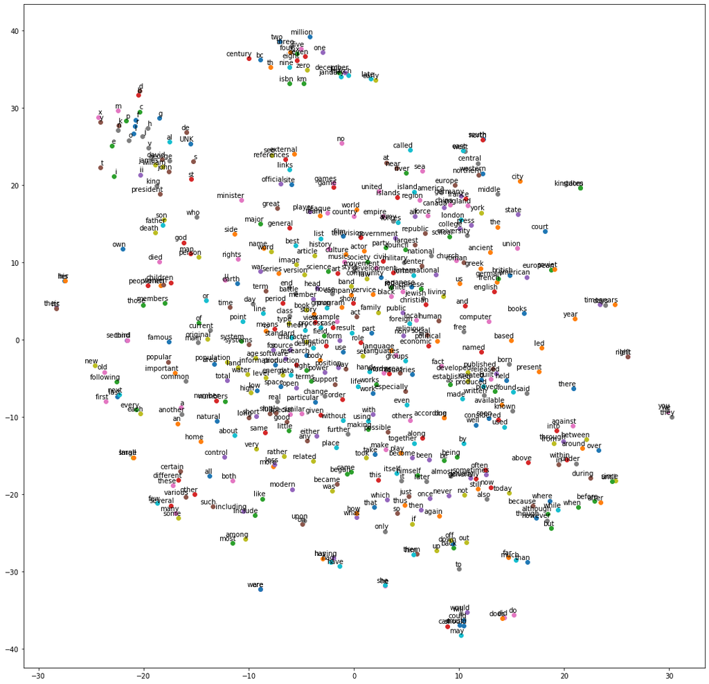

```python
from sklearn.manifold import TSNE

tsne = TSNE(perplexity=30, n_components=2, init='pca', n_iter=5000, method='exact')
plot_only = 500
final_embeddings = embedding_matrix
low_dim_embs = tsne.fit_transform(final_embeddings[:plot_only, :])
labels = [id_to_word[i] for i in range(plot_only)]
plot_with_labels(low_dim_embs, labels)
```

### Cosine Similarity

[cosine similarity](https://en.wikipedia.org/wiki/Cosine_similarity) is a metrics for evaluating the similarity between two vectors. $$ \newcommand{\norm}[1]{\left\lVert#1\right\rVert} \textrm{similarity} = \cos(\theta) = \frac{\textrm{A} \cdot \textrm{B}}{\norm{\textrm{A}} \cdot \norm{\textrm{B}}} $$

```python
import numpy.linalg as LA
```

```python
# handy method for calculating the similarity between 2 word
def cos_sim(word1, word2):
    id1 = word_to_id[word1]
    id2 = word_to_id[word2]

    vec1 = embedding_matrix[id1].numpy()
    vec2 = embedding_matrix[id2].numpy()

    return np.dot(vec1, vec2) / (LA.norm(vec1) * LA.norm(vec2))
```

```python
cos_sim('man', 'woman')
```

```
0.9251495
```

```python
def top_k_nearest(word, k):
    vec = embedding_matrix[word_to_id[word]]

    # calaulate cosine similarity  of `vec` and all other vocabularies
    dot = np.dot(embedding_matrix.numpy(), vec)
    embedding_norm = LA.norm(embedding_matrix.numpy(), axis=-1)
    vec_norm = LA.norm(vec)
    norm_product = embedding_norm * vec_norm
    cos_sim = dot / norm_product

    # print out top k nearest words
    indices = np.argsort(cos_sim)[::-1][:k]
    print('---top {} nearest words of {}---'.format(k, word))
    for idx in indices:
        print(id_to_word[idx])
    print('------')
```

```python
top_k_nearest('beautiful', 5)
top_k_nearest('people', 5)
```

```
---top 5 nearest words of beautiful---
beautiful
prestigious
fertile
prosperous
prolific
------
---top 5 nearest words of people---
people
men
jews
women
students
------
```

# TO-DO

1. Devise Word2Vec model by subclassing keras.Model

```python
from tensorflow.keras import Model

class Word2Vec(Model):
    def __init__(self):
        '''To-Do: Define model variables'''

    def call(self, center_words, target_words):
        '''To-Do: Define data flow and return loss'''
```

1. Train your word2vec model and plot your learning curve
2. Visualize your embedding matrix by t-SNE
3. Show top-5 nearest neighbors of "beautiful" and "people"
4. Submit to iLMS with your **ipynb** (Lab11_{student_id}.ipynb).
- Deadline: 2019-10-31(Thur) 23:59